# R Homework Assignment

Mamoon Y. Ismail, Jeeban Panthi, Tiare Fridrich

2018-03-30

**BOLD**

*ITALICS*

1- The backticks (`) indicate code

2- r indicates R code

3- In-line code: is how to include r code results into text

The version of R is 3.4.3

4- Itâs usually best to give each code chunk a name, like chunk_name ```{r chunk_name}

5- echo=FALSE indicates that the code will not be shown in the final document like this ```{r chunk_name, echo=FALSE}

6- Use results=“hide” to hide the results/output (but here the code would still be displayed), ```{r chunk_name, results=“hide”}

7- Use include=FALSE to have the chunk evaluated, but neither the code nor its output displayed, ```{r chunk_name, include=FALSE}

8- For figures, youâll want to use options like fig.width and fig.height. For example: {r scatterplot, fig.width=8, fig.height=6}. Note that if include=FALSE, all of the code, results, and figures will be suppressed. If include=TRUE and results=“hide”, the results will be hidden but figures will still be shown. To hide the figures, use fig.show=“hide”. NOTE: results=hide is wrong; you need results=“hide”.

9- Global chunk options: use the same set of chunk options throughout a document to avoid retype it in every chunk, so you want to set some global chunk options at the top of your document. For example, I might use include=FALSE or at least echo=FALSE globally for a report to a scientific collaborator who wouldnât want to see all of the code. And I might want something like fig.width=12 and fig.height=6 if I generally want those sizes for my figures.

10- If you want a particular chunk to have a different behavior, for example, to have a different figure height, youâd specify a different option within that chunk. For example: {r a_taller_figure, fig.height=32}.

### Loading librarry

A chunk needed to load the library

```r
library(tidyverse)
```

## Global Options

```r
#These are default settings eg fig size or whether you print code
knitr::opts_chunk$set(echo = TRUE, warning=FALSE, message=FALSE,
                      fig.width=12, fig.height=8, fig.path='figs/')
```

## SURVEYS

This is a survey data that has been collected about animal species.

### Reading Data

Reading Colected data into a file called survey

```r
surveys <- read_csv("~/Desktop/rclass/homework/Assignment-3R/data_output/surveys_NAsrem.csv")
```

## Plotting

Add plots of different relations

These are the packages we need to deal with

```r
library(tidyverse)
library(ggplot2)
library(lubridate)
library(gridExtra)
library(dplyr)
library(ggpubr)
library(Hmisc)
```

### 1. Relationship between sex and hindfoot length

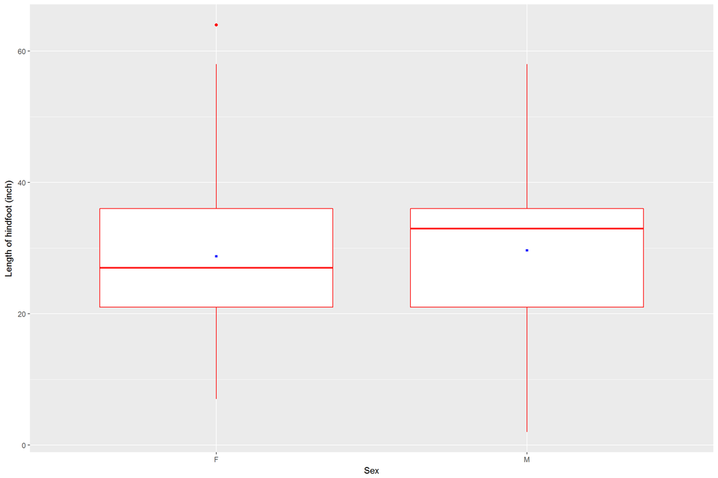

```r
ggplot(surveys, aes(x=sex, y=hindfoot_length))+geom_boxplot(alpha = 1, color='red')+xlab('Sex')+ylab('Length of hindfoot (inch)')+stat_summary(fun.y=mean, color="blue", geom="point",  shape=15, size=1,show_guide = T, show.legend = T)
```

Figure 1: Hindfoot length for male and female. The blue dot indicates the mean (average) hindfoot length.

### 2. Number of individuals of each of the species classfied by sex

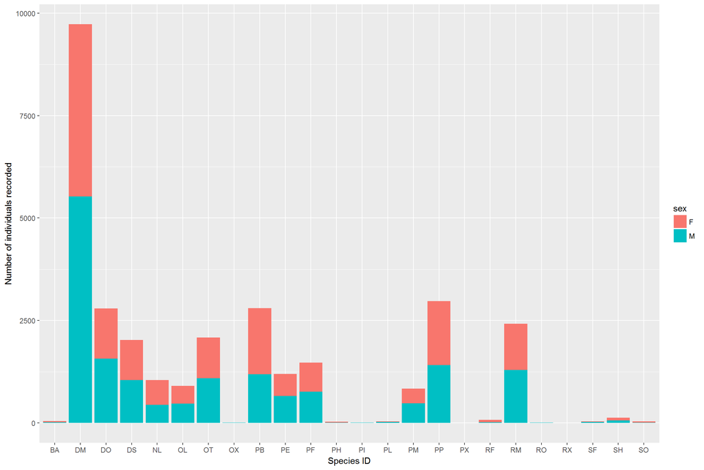

```r
ggplot(surveys, aes(species_id))+geom_bar(aes(fill=sex))+ylab('Number of individuals recorded')+xlab('Species ID')
```

Figure 2: Number of individuals of each of the species classfied by sex

# 3. Correlationship between weight and hindfoot length

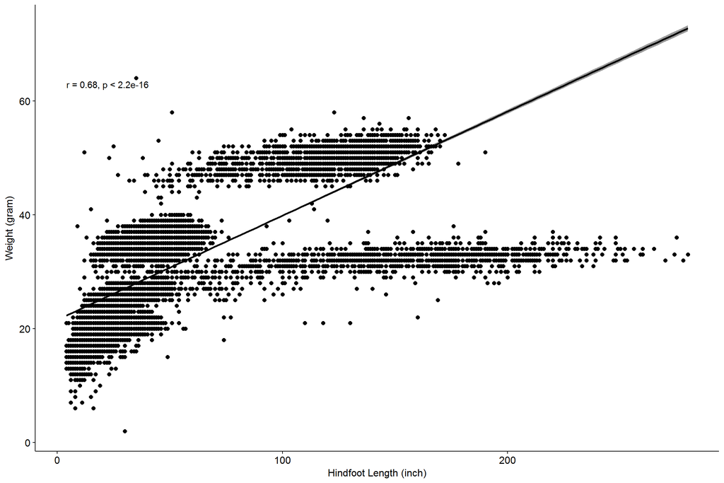

```r
ggscatter(surveys, x = "weight", y = "hindfoot_length",  add = "reg.line", conf.int = TRUE, cor.coef = TRUE, cor.method = "pearson",  xlab = "Hindfoot Length (inch)", ylab = "Weight (gram)")
```

Figure 3: Scatter plot showing the correlation between weight and hindfoot length of species

The p-value of the test is less than the significance level alpha = 0.05. We can conclude that weight and hindfoot length are significantly positively correlated with a correlation coefficient of 0.68 and p-value of 2.2*10^{-16}

# 4.4. Hindfoot length of different species

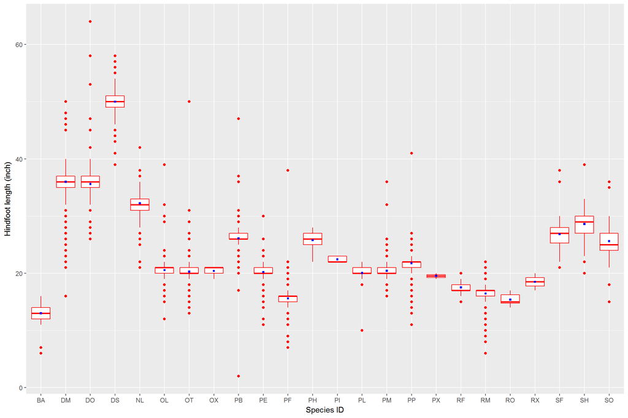

```r
ggplot(data = surveys, aes(x = species_id, y = hindfoot_length)) +  geom_boxplot(alpha=1, color='red')+xlab('Species ID')+ylab('Hindfoot length (inch)')+stat_summary(fun.y=mean, color="blue", geom="point",  shape=15, size=1,show_guide = T, show.legend = T)
```

Figure 4: Box plot of hindfoot length of different species. The blue dot indicates the average (mean) hindfoot length.